# Day 1 code

Author

Constantin Manuel Bosancianu

Published

January 20, 2021

# 1 Introduction

I have to assume sufficient baseline knowledge of R, so we will start directly with some more advanced procedures. If you feel we’re going to fast, please come see me after the first session ends, and I can suggest a few materials you can consult before the next few labs.

Irrespective of which text editor you are using, when compiling this code file the working directory will automatically be set to the folder where this code file is located in. If you want to run the code line by line, you set the working directory on your own. You can check the current working directory with the `getwd()` function, and you can set a new working directory with the `setwd()` function.

All scripts assume that you are in the directory where the code file is placed: “./01-code”. They further assume that in the main “Multilevel” project folder you have the following subfolders: - “02-data” - “03-graphs”

If you have this folder structure in place, the code file should work from beginning to end without an error.[^1]

<sup>1</sup> As you’ve discovered so far, **R** is case-sensitive: it will produce an error if you’re trying to read data from the `./02-Data` folder instead of the `02-data` one.

Helpful tips: - when you don’t remember the arguments for a function, make use of the `help()` function - when you don’t remember how to extract elements from an object (vector, matrix, list, statistical output), turn to the `str()` function - if you’re missing a package on your machine, quickly install it with the following snippet of code: `install.packages("package_name", dep = TRUE, repos = "https://cran.rstudio.com")`

Though the code has been written entirely from scratch, and I have replaced most of the empirical examples, a lot of the logic of the sequences is inspired by the precursor to this course, taught by Zoltan Fazekas. I was a TA for that course for a number of years, and have learned a great deal in the process.

**Warning**: the code chunk below will install packages on your system (if these are not already installed).

```r
library(pacman)
p_load(tidyverse, broom, ggeffects, texreg, arm, knitr,
       broom.mixed, kableExtra, magrittr, ggthemes)
```

The `p_load()` function from the `pacman` package looks for the collection of packages you specify on your machine. If it finds them, it loads them in the working environment; if it doesn’t, it downloads them, installs them, and then loads them.

# 2 Reading data

The code chunk below assumes that the data set is in the `02-data` folder. This means we have to go one folder up from the code folder, and then into the data folder.

```r
df_issp <- readRDS("../02-data/01-ISSP.rds")
```

We will be using a lot of functions from the `dplyr` package and from some of the other packages that make up the `tidyverse`. Despite some opinions to the contrary (https://github.com/matloff/TidyverseSkeptic), I believe it is a very elegant way of thinking about coding, and one which I think will grow in importance. It pays off to learn it early and well.

The pipe operator (`%>%`) serves to take the output from a line of code, and feed it as input into the next line of code. It can be loosely translated as “with this… do that…”.

```r
df_issp %>%
    glimpse()
```

```
Rows: 51,713
Columns: 40
$ educ        <dbl> 16, NA, 20, 11, 18, 20, 18, 17, 20, 17, 18, 17, NA, 15, NA…
$ degree      <dbl+lbl> 3, 3, 5, 4, 3, 5, 6, 6, 6, 5, 6, 6, 4, 6, 5, 6, 6, 5, …
$ unemp       <dbl> 0, NA, 0, 0, 0, 0, 0, 0, 0, 1, 0, 0, 0, 0, 0, NA, 0, 0, 0,…
$ place       <dbl+lbl>  4, NA,  3,  6,  7,  3,  6,  4,  6,  6,  5,  9,  3,  9…
$ cnt         <chr> "AU", "AU", "AU", "AU", "AU", "AU", "AU", "AU", "AU", "AU"…
$ V41         <dbl+lbl>  2, NA,  1,  2,  1,  4, NA,  1,  4,  4,  3,  4,  5,  1…
$ V42         <dbl+lbl>  2, NA,  1,  2,  1,  2, NA,  1,  2,  4,  3,  4,  5,  1…
$ V43         <dbl> 5, NA, 4, 4, 2, 4, NA, 4, 5, 4, 4, 4, 4, 5, 4, 4, 3, 4, 5,…
$ V44         <dbl+lbl>  4, NA,  3,  4,  3,  5, NA,  5,  4,  3,  4,  4,  5,  3…
$ female      <dbl+lbl> 1, 0, 0, 1, 1, 1, 0, 0, 1, 0, 1, 0, 0, 1, 1, 0, 1, 1, …
$ age10       <dbl+lbl> 2.5, 5.5, 4.0, 5.7, 3.2, 2.4, 6.7, 3.9, 4.1, 3.6, 3.5,…
$ married     <dbl> 1, 1, 0, NA, 1, 0, 1, 1, 1, 0, 1, 1, 1, 0, 0, 1, 1, 1, NA,…
$ unmemb      <dbl> 0, 0, 0, 0, 1, 0, 0, 0, 1, 0, 1, 0, 0, 0, 0, 1, 1, 0, 0, 0…
```

[output cut: 27 more lines]

# 3 Codebook

Many variables added there; please check the codebook for this data set (**Codebook-ISSP.pdf**, located in the `./05-docs` folder).

The most important ones for our purposes here are: 1. `cnt`: a 2-letter code for the country from which the respondent comes from 2. `poleff`: an index of political efficacy, obtained as a mean of `V41`, `V42`, `V43` and `V44`. Higher values denote a higher level of political efficacy 3. `female`: a dummy indicator for gender (1 = woman; 0 = man) 4. `age10`: continuous indicator for age, measured in decades (32 years = 3.2 decades) 5. `educ`: number of years of full time education completed 6. `incquart`: a country-specific placement on a 4-point income ranking (1=lowest 25% income…….. 4 = highest 25% income) 7. `year`: year of the survey 8. `country`: full name of the country

We will keep only the variables we’re interested in.[^2]

<sup>2</sup> The function `select()` is found in multiple packages, so putting `dplyr::` in the beginning just ensures that `R` knows to use the `select()` function found in that specific package.

```r
df_issp <- df_issp %>%
    dplyr::select(cnt, year, country, poleff, female,
                  age10, educ, urban, incquart, ti_cpi) %>%
    na.omit() %>%
    mutate(female = as.factor(female),
           urban = as.factor(urban),
           incquart = as.factor(incquart))
```

# 4 Complete vs. No pooling

## 4.1 Complete pooling

**Complete pooling** designates a specification that uses the entire sample to estimate the relationship between predictors and outcome, without any thought given to group membership.

```r
model1.complete <- lm(poleff ~ 1 + age10 + female + educ + urban +
                        incquart,
                      data = df_issp)

summary(model1.complete)
```

```
Call:
lm(formula = poleff ~ 1 + age10 + female + educ + urban + incquart,
    data = df_issp)

Residuals:
    Min      1Q  Median      3Q     Max
-2.4885 -0.5166 -0.0156  0.5074  6.2614

Coefficients:
              Estimate Std. Error t value Pr(>|t|)
(Intercept)  2.1664803  0.0194776 111.229  < 2e-16 ***
age10        0.0346543  0.0022664  15.291  < 2e-16 ***
female1     -0.1433696  0.0076376 -18.772  < 2e-16 ***
educ         0.0434269  0.0009875  43.976  < 2e-16 ***
urban1       0.0873506  0.0077367  11.290  < 2e-16 ***
incquart2    0.0710817  0.0108540   6.549 5.87e-11 ***
incquart3    0.1337318  0.0110176  12.138  < 2e-16 ***
incquart4    0.2537740  0.0113588  22.342  < 2e-16 ***
---
Signif. codes:  0 '***' 0.001 '**' 0.01 '*' 0.05 '.' 0.1 ' ' 1

Residual standard error: 0.7372 on 37620 degrees of freedom
Multiple R-squared:  0.09817,   Adjusted R-squared:  0.098
F-statistic:   585 on 7 and 37620 DF,  p-value: < 2.2e-16
```

A much nicer-formatted display is available in the family of functions available in the `texreg` package.

```r
htmlreg(list(model1.complete),
        digits = 3,
        single.row = FALSE,
        inline.css = TRUE,
        html.tag = FALSE,
        head.tag = FALSE,
        body.tag = FALSE)
```

Statistical models

|  | Model 1 |
| --- | --- |
| (Intercept) | 2.166*** |
|  | (0.019) |
| age10 | 0.035*** |
|  | (0.002) |
| female1 | -0.143*** |
|  | (0.008) |
| educ | 0.043*** |
|  | (0.001) |
| urban1 | 0.087*** |
|  | (0.008) |
| incquart2 | 0.071*** |
|  | (0.011) |
| incquart3 | 0.134*** |
|  | (0.011) |
| incquart4 | 0.254*** |
|  | (0.011) |
| R<sup>2</sup> | 0.098 |
| Adj. R<sup>2</sup> | 0.098 |
| Num. obs. | 37628 |

***p < 0.001; **p < 0.01; *p < 0.05

Based on this model, all we can say is that the effect of education, or gender, on political efficacy is the same for every respondent, irrespective of which country they come from. Its virtue is that it uses information from the entire sample to estimate the relationship, which results in very small standard errors.

## 4.2 No pooling

The alternative is the **no pooling** approach: running each model separately for each group. This will easily uncover how an effect varies between different countries in our sample. We can use two functions to quickly produce this: `nest()` from the `tidyr` package, and `map()` from the `purrr` package.

```r
df_nopool <- df_issp %>%
  dplyr::select(poleff, age10, female, educ, urban, incquart, cnt) %>%
  nest(data = -cnt) %>%
  mutate(mod1 = map(data,
                    ~lm(poleff ~ 1 + age10 + female + educ +
                          urban + incquart,
                        data = .)),
         results = map(mod1, tidy)) %>%
  unnest(results) %>%
  dplyr::select(-data, -mod1)
```

```r
df_nopool %>%
    slice(1:10) %>%
    kable(digits = 3,
          caption = "Estimates from no pooling model",
          caption.above = TRUE,
          col.names = c("Country", "Variable", "Est.", "SE",
                        "t value", "p")) %>%
    kable_styling(full_width = TRUE)
```

Estimates from no pooling model

| Country | Variable | Est. | SE | t value | p |
| --- | --- | --- | --- | --- | --- |
| AU | (Intercept) | 2.027 | 0.159 | 12.745 | 0.000 |
| AU | age10 | 0.104 | 0.017 | 6.248 | 0.000 |
| AU | female1 | -0.067 | 0.048 | -1.400 | 0.162 |
| AU | educ | 0.040 | 0.007 | 5.733 | 0.000 |
| AU | urban1 | 0.007 | 0.049 | 0.138 | 0.890 |
| AU | incquart2 | 0.001 | 0.069 | 0.009 | 0.993 |
| AU | incquart3 | 0.238 | 0.073 | 3.245 | 0.001 |
| AU | incquart4 | 0.253 | 0.073 | 3.449 | 0.001 |
| AT | (Intercept) | 1.516 | 0.163 | 9.290 | 0.000 |
| AT | age10 | 0.062 | 0.016 | 3.918 | 0.000 |

Looking at the raw numbers doesn’t help us very much, even if we were to filter by the effect we’re interested in. A graphical display would be more powerful in this case.

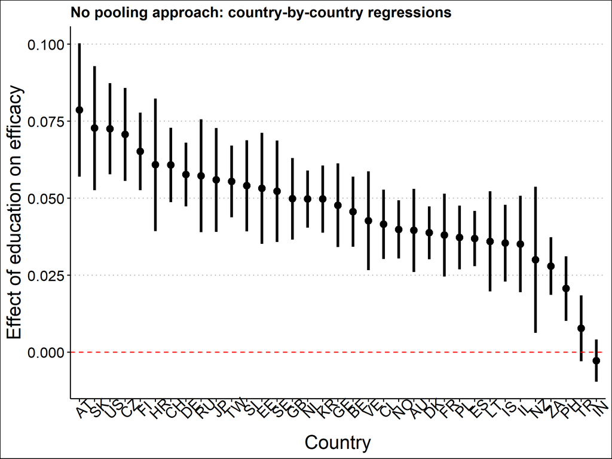

```r
df_nopool %>%
  filter(term == "educ") %>%
  ggplot(aes(x = reorder(cnt, -estimate), # Reorder from low to high
             y = estimate)) +
  geom_point(size = 3) +
  geom_errorbar(aes(ymin = estimate - 1.96 * std.error, # Construct CIs
                    ymax = estimate + 1.96 * std.error),
                width = 0, linewidth = 1.25) +
  labs(x = "Country",
       y = "Effect of education on efficacy",
       title = "No pooling approach: country-by-country regressions") +
  theme_clean() +
  geom_hline(yintercept = 0, # Create dashed line denoting no effect
             linetype = "dashed",
             color = "red") +
  theme(axis.title = element_text(size = 18),
        axis.text.x = element_text(size = 14, angle = 45),
        axis.text.y = element_text(size = 14))
```

The challenge with this approach is that the only information used in the estimation originates with the group itself. Take as an example the case of Poland. Suppose that instead of 1,892 cases, it had 190 observations (about 10% of the original sample).

```r
set.seed(395722)
df_pl <- df_issp %>%
    filter(cnt == "PL") %>%
    slice_sample(n = 190)

df_issp_temp <- rbind(filter(df_issp, !(cnt == "PL")),
                      df_pl)
rm(df_pl)
```

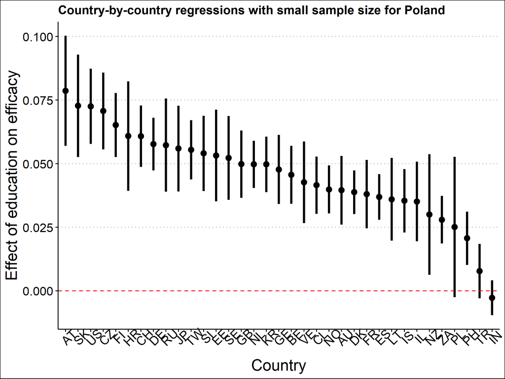

```r
df_issp_temp %>%
    dplyr::select(poleff, age10, female, educ, urban, incquart, cnt) %>%
    nest(data = -cnt) %>%
    mutate(mod1 = map(data,
                      ~lm(poleff ~ 1 + age10 + female + educ +
                              urban + incquart,
                          data = .)),
           results = map(mod1, tidy)) %>%
    unnest(results) %>%
    filter(term == "educ") %>%
    ggplot(aes(x = reorder(cnt, -estimate),
               y = estimate)) +
    geom_point(size = 3) +
    geom_errorbar(aes(ymin = estimate - 1.96 * std.error,
                      ymax = estimate + 1.96 * std.error),
                  width = 0, linewidth = 1.25) +
    labs(x = "Country",
         y = "Effect of education on efficacy",
         title = "Country-by-country regressions with small sample size for Poland") +
    geom_hline(yintercept = 0,
               color = "red",
               linetype = "dashed") +
    theme_clean() +
    theme(axis.title = element_text(size = 18),
          axis.text.x = element_text(size = 14, angle = 45),
          axis.text.y = element_text(size = 14))
```

# 5 Multilevel model: random intercepts

We will use the `lmer()` function from the `lme4` package for these models. I have loaded the `arm` package because this automatically calls the `lme4` package, but also makes available some additional post-estimation function designed by Gelman and Hill.

## 5.1 First model

```r
mlm.1 <- lmer(formula = poleff ~ age10 + female + educ + urban +
                    incquart + (1 | cnt),
              data = df_issp_temp,
              REML = TRUE,
              control = lmerControl(optimizer = "bobyqa"))
```

```r
summary(mlm.1)
```

```
Linear mixed model fit by REML ['lmerMod']
Formula: poleff ~ age10 + female + educ + urban + incquart + (1 | cnt)
   Data: df_issp_temp
Control: lmerControl(optimizer = "bobyqa")

REML criterion at convergence: 75463.2

Scaled residuals:
    Min      1Q  Median      3Q     Max
-4.0522 -0.6756 -0.0086  0.6761  8.7607

Random effects:
 Groups   Name        Variance Std.Dev.
 cnt      (Intercept) 0.07969  0.2823
 Residual             0.47526  0.6894
Number of obs: 35926, groups:  cnt, 35

Fixed effects:
             Estimate Std. Error t value
(Intercept)  2.181295   0.051973  41.969
age10        0.037562   0.002289  16.411
female1     -0.119981   0.007337 -16.352
educ         0.040801   0.001055  38.671
urban1       0.052275   0.007956   6.570
incquart2    0.074163   0.010397   7.133
incquart3    0.145622   0.010561  13.788
incquart4    0.274052   0.010937  25.057

Correlation of Fixed Effects:
          (Intr) age10  femal1 educ   urban1 incqr2 incqr3
age10     -0.287
female1   -0.088  0.023
educ      -0.271  0.241  0.001
urban1    -0.033  0.006 -0.010 -0.132
incquart2 -0.089  0.025  0.035 -0.089  0.005
incquart3 -0.085  0.081  0.056 -0.166  0.001  0.514
incquart4 -0.057  0.085  0.078 -0.273 -0.040  0.509  0.538
```

Take a while to look a bit at the result output - looks fairly similar to that from the `lm()` function in how it is structured, except that it has a few additional fields: “Random effects” and “Correlation of Fixed Effects”.[^3]

<sup>3</sup> Why no stars for the output? Because that’s how the original creator of the package wanted it, for very good reasons: https://stat.ethz.ch/pipermail/r-help/2006-May/094765.html.

## 5.2 Quantities of interest

You can use a few functions to obtain the fixed effects and random effects from the model.

```r
fixef(mlm.1) # The fixed effects
```

```
(Intercept)       age10     female1        educ      urban1   incquart2
 2.18129505  0.03756219 -0.11998081  0.04080067  0.05227496  0.07416305
  incquart3   incquart4
 0.14562156  0.27405200
```

```r
se.fixef(mlm.1) # SEs for the fixed effects
```

```
(Intercept)       age10     female1        educ      urban1   incquart2
0.051973390 0.002288866 0.007337178 0.001055084 0.007956337 0.010396738
  incquart3   incquart4
0.010561201 0.010937097
```

In our case, only a random intercept was specified.

```r
ranef(mlm.1) # The random effects (deviations) in the model
```

```
$cnt
    (Intercept)
AT -0.079046536
AU  0.185513336
BE -0.070355330
CH  0.358958236
CL  0.160816209
CZ -0.348662867
DE  0.164106843
DK  0.262411031
EE -0.163769325
ES -0.122897151
FI  0.036102695
FR  0.422218729
GB  0.070563337
GE -0.231100699
HR -0.334343686
IL -0.325110430
IN -0.056706716
IS  0.381873621
JP  0.112741210
KR -0.287513101
LT -0.442944016
NL  0.165818359
NO  0.439128014
NZ  0.216195571
PH  0.107139782
PL -0.376924828
RU -0.177407522
SE  0.242468686
SI -0.544443801
SK -0.350349731
TR  0.326741456
TW -0.074066926
US  0.003829425
VE  0.509646272
ZA -0.180630147

with conditional variances for "cnt"
```

```r
# The SEs for random effects (function from the "arm" package).
se.ranef(mlm.1)
```

```
$cnt
   (Intercept)
AT  0.02537751
AU  0.02411932
BE  0.01677476
CH  0.02181180
CL  0.02295471
CZ  0.02048134
DE  0.01790198
DK  0.01679466
EE  0.03014607
ES  0.02000161
FI  0.02219274
FR  0.02677451
GB  0.01898955
GE  0.01995965
HR  0.02689650
IL  0.02572854
IN  0.02120491
IS  0.02502395
JP  0.02002691
KR  0.01868029
LT  0.02529197
NL  0.01881197
NO  0.01967314
NZ  0.02908120
PH  0.02001003
PL  0.04924686
RU  0.02471649
SE  0.02465319
SI  0.02860171
SK  0.02187760
TR  0.02092950
TW  0.01889659
US  0.02032056
VE  0.02255804
ZA  0.01467136
```

Alternatively, you can use a function in the `broom.mixed` package that extracts the same quantities (for the first 20 countries in the sample).

```r
tidy(mlm.1) %>%
    kable(caption = "Tidied output for multilevel model",
          digits = 3,
          col.names = c("Effect", "Group", "Variable", "Est.",
                        "SE", "t value")) %>%
    kable_styling(full_width = TRUE)
```

Tidied output for multilevel model

| Effect | Group | Variable | Est. | SE | t value |
| --- | --- | --- | --- | --- | --- |
| fixed | NA | (Intercept) | 2.181 | 0.052 | 41.969 |
| fixed | NA | age10 | 0.038 | 0.002 | 16.411 |
| fixed | NA | female1 | -0.120 | 0.007 | -16.352 |
| fixed | NA | educ | 0.041 | 0.001 | 38.671 |
| fixed | NA | urban1 | 0.052 | 0.008 | 6.570 |
| fixed | NA | incquart2 | 0.074 | 0.010 | 7.133 |
| fixed | NA | incquart3 | 0.146 | 0.011 | 13.788 |
| fixed | NA | incquart4 | 0.274 | 0.011 | 25.057 |
| ran_pars | cnt | sd__(Intercept) | 0.282 | NA | NA |
| ran_pars | Residual | sd__Observation | 0.689 | NA | NA |

```r
augment(ranef(mlm.1),
        ci.level = 0.95) %>%
    slice(1:20) %>%
    kable(caption = "Augmented output for multilevel model",
          digits = 3,
          col.names = c("Group", "Variable", "Country", "Est.",
                        "QQ", "SE", "Lower CI", "Upper CI")) %>%
    kable_styling(full_width = TRUE)
```

Augmented output for multilevel model

| Group | Variable | Country | Est. | QQ | SE | Lower CI | Upper CI |
| --- | --- | --- | --- | --- | --- | --- | --- |
| cnt | (Intercept) | SI | -0.544 | -0.291 | 0.025 | -0.594 | -0.495 |
| cnt | (Intercept) | LT | -0.443 | 0.608 | 0.024 | -0.490 | -0.396 |
| cnt | (Intercept) | PL | -0.377 | -0.144 | 0.017 | -0.410 | -0.344 |
| cnt | (Intercept) | SK | -0.350 | 1.133 | 0.022 | -0.393 | -0.308 |
| cnt | (Intercept) | CZ | -0.349 | 0.366 | 0.023 | -0.394 | -0.304 |
| cnt | (Intercept) | HR | -0.334 | -1.133 | 0.020 | -0.374 | -0.294 |
| cnt | (Intercept) | IL | -0.325 | 0.444 | 0.018 | -0.360 | -0.290 |
| cnt | (Intercept) | KR | -0.288 | 0.894 | 0.017 | -0.320 | -0.255 |
| cnt | (Intercept) | GE | -0.231 | -0.444 | 0.030 | -0.290 | -0.172 |
| cnt | (Intercept) | ZA | -0.181 | -0.366 | 0.020 | -0.220 | -0.141 |
| cnt | (Intercept) | RU | -0.177 | 0.072 | 0.022 | -0.221 | -0.134 |
| cnt | (Intercept) | EE | -0.164 | 1.465 | 0.027 | -0.216 | -0.111 |
| cnt | (Intercept) | ES | -0.123 | 0.144 | 0.019 | -0.160 | -0.086 |
| cnt | (Intercept) | AT | -0.079 | -0.697 | 0.020 | -0.118 | -0.040 |
| cnt | (Intercept) | TW | -0.074 | -1.006 | 0.027 | -0.127 | -0.021 |
| cnt | (Intercept) | BE | -0.070 | -0.894 | 0.026 | -0.121 | -0.020 |
| cnt | (Intercept) | IN | -0.057 | -0.072 | 0.021 | -0.098 | -0.015 |
| cnt | (Intercept) | US | 0.004 | 1.282 | 0.025 | -0.045 | 0.053 |
| cnt | (Intercept) | FI | 0.036 | 0.291 | 0.020 | -0.003 | 0.075 |
| cnt | (Intercept) | GB | 0.071 | -0.792 | 0.019 | 0.034 | 0.107 |